# Sentence pause duration

Between sentence pause duration correction

2020-06-17

```r
library(dplyr)
library(rPraat)
library(ggplot2)
library(fitdistrplus)
library(readxl)
```

# Introduction

In this markdown document, you can read how we process the raw recordings to the recordings how they are published.

# Misread passages

Here you can find an overview of all discrepancies between text and recording; `in both` indicates that the same discrepancy occurred in both speakers

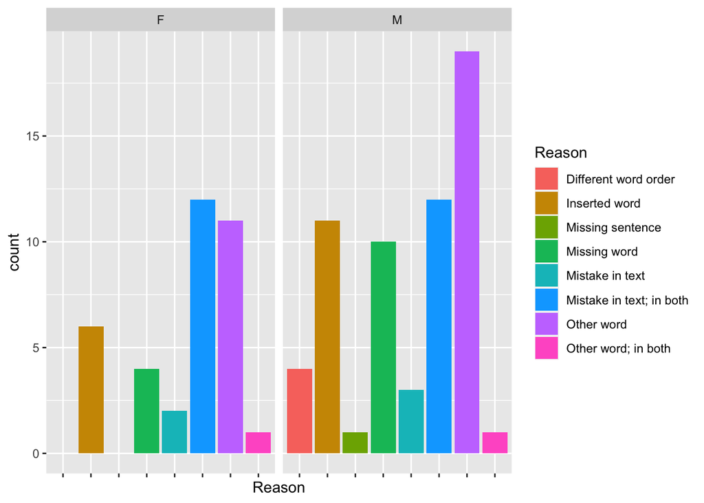

```r
mistakes_df = read_excel('../data/stories/original/annotated_mistakes.xlsx')
mistakes_df %>%
  group_by(Reason, Gender) %>%
  summarise(count = length(Reason)) %>%
  ggplot() +
  geom_bar(aes(x = Reason, y = count, fill = Reason), stat = "identity") +
  facet_wrap(. ~ Gender) +
  theme(axis.text.x = element_blank())
```

# Correcting the pause durations between sentences

## Story corpus distribution

```r
source('split_sentences_story_corpus.R')
```

Once we have this information, we can simply extract the BSP by taking the pause between the last word of the preceding sentence and the first word of the next sentence:

```r
# Grab the text grid files
ORIGINAL_STORIES_PATH = '../data/stories/original/'
sentence_duration = read.csv(paste0(ORIGINAL_STORIES_PATH, 'durations_all_stories_and_speakers.csv'))
durations = c()
for (g in c('M', 'F')) {
  for (s in 1:8) {
    filt_df = filter(sentence_duration, gender == g, story == s)
    # just take the pause between the last word of the preceding sentence and the first word of the next sentence
    durations = c(durations, filt_df$start[2:nrow(filt_df)] - filt_df$end[1:(nrow(filt_df) - 1)])
  }
}

story_corpus = data.frame(duration = durations)
```

## Other corpora

In order to have some comparison to other BSPs, we extract a BSP from manually checked transcripts of Goethe’s *Die Wahlverwandtschaften* and automatically generated transcripts for stories from *Librivox*. Even though both stories are in different languages (English and German), they allow to compare BSPs computed using manually checked and automatically generated transcripts.

### Goethe

The first chapter of Goethe’s *Die Wahlverwandtschaften* was read by 8 German speakers. All the phonological transcripts were manually set and checked.

```r
# HELPER FUNCTIONS
# This removes special characters
remove_special_chars = function(labs, forbidden_chars = c(',', '-', ';')) {
  labs = stringr::str_replace_all(labs, '—', ' ')
  labs = stringr::str_remove_all(labs, paste(forbidden_chars, collapse = '|'))
  labs = tolower(labs)
  return(labs)
}

# This finds the end of the sentence based on a list of end of sentence interpunctions (e.g. the dot marking the end of a sentence)
get_end_of_sentence = function(words, sentence_end_interpunction = c('.'), include_quotes = FALSE) {
  return(
    unlist(
      lapply(words, function(word) {
        word_len = nchar(word)
        # Check which words end with a end of sentence interpunction (e.g., . or ? or !)
        if (substr(word, word_len, word_len) %in% sentence_end_interpunction) {
          # If we want to exclude quotes
          if (!include_quotes) {
            # Check if the last character before the end of sentence interpunction is not a “
            if (substr(word, word_len - 1, word_len - 1) != "“") {
              return(TRUE)
            }
          } else {
            # i.e. include quotes
            return(TRUE)
          }
        }
        # return FALSE by default
        return(FALSE)
      })
    )
  )
}
```

Let’s first load the relevant text and remove special characters

```r
GOETHE_PATH = '../data/sentence_pause_estimation/goethe/'
# Load basis txt
con = file(paste0(GOETHE_PATH, 'goethe_fragment.txt'), "r")
txt = remove_special_chars(readLines(con, n = 1))
close(con)
```

Now split the story into words and grab the end of the sentence. Please note that we reject ends of sentences within quotes, e.g. *„Hast du meine Frau nicht gesehen?“* in *„Hast du meine Frau nicht gesehen?“ fragte Eduard, indem er …*. We only include sentences that end with a dot **(.)**.

```r
# Get words
word_sep_txt = strsplit(txt, " ")[[1]]

# Get word end, exclude quotes and only dots ('.')
sentence_end = get_end_of_sentence(word_sep_txt)

# Remove special chars
word_sep_txt = stringr::str_remove_all(word_sep_txt, paste(c('\\.', '„', '\\?', '“', ':', '!'), collapse = "|"))
```

Next, we grab all TextGrids and iterate through them. For a later pause duration normalisation, we also save the length of single sentences.

```r
tg_names = list.files(GOETHE_PATH, '.TextGrid')
pauses = NULL
for (tg_name in tg_names) {
  # Read the text grid
  tg = tg.read(paste0(GOETHE_PATH, tg_name), encoding = "auto")

  # Grab the indexes of the not pauses
  idx = !tg$`ORT-MAU`$label %in% c("", "<p:>")

  # Remove any special characters
  labels = remove_special_chars(tg$`ORT-MAU`$label[idx])

  # Map all words to the interval index on the textgrid tier
  look_up_df = data.frame(
    label = labels,
    idx = which(idx)
  )

  # Compute pauses, i.e. the interval after the last word of the sentence
  pause_idxs = look_up_df[which(sentence_end), "idx"] + 1
  pause_nb = 1:length(pause_idxs)
  # Check if the next interval after the end of the sentence is really a pause and not already the first word of the next sentence!
  if (!all(tg$`ORT-MAU`$label[pause_idxs] %in% c("", "<p:>"))) {
    warning(paste('Pause missing after sentence:'))
    idxs = tg$`ORT-MAU`$label[pause_idxs] %in% c("", "<p:>")
    pause_idxs = pause_idxs[idxs]
    pause_nb = pause_nb[idxs]
  }

  # Extract pause durations
  durations = tg$`ORT-MAU`$t2[pause_idxs] - tg$`ORT-MAU`$t1[pause_idxs]

  # Compute the duration of sentences for speaker normalisation
  sentence_starts = tg$`ORT-MAU`$t1[c(min(which(!tg$`ORT-MAU`$label %in% c("", "<p:>"))), (pause_idxs + 1))]
  sentence_ends = tg$`ORT-MAU`$t2[c(pause_idxs - 1, max(which(!tg$`ORT-MAU`$label %in% c("", "<p:>"))))]
  sentence_durations = (pause_idxs[-1] + 1)

  syllable_rate = c()

  for (i in 1:length(sentence_starts)) {
    t1 = sentence_starts[i]
    t2 = sentence_ends[i]
    idxs = tg$`KAS-MAU`$t1 >= t1 & tg$`KAS-MAU`$t2 < t2
    labels = tg$`KAS-MAU`$label[idxs]
    labels = labels[!labels %in% c("", "<p:>")]
    num_syllables = length(labels) + length(unlist(stringr::str_match_all(labels, "\\.")))
    syllable_rate = c(syllable_rate, num_syllables / (t2 - t1))
  }

  # Add the info
  pauses = rbind(pauses, data.frame(
    speaker = strsplit(tg_name, "_")[[1]][1],
    duration = durations,
    pause_nb = pause_nb,
    sentence_duration = (sentence_ends - sentence_starts)[-1],
    syllable_rate = syllable_rate[-1]
  ))
}
```

```
## Warning: Pause missing after sentence:

## Warning: Pause missing after sentence:

## Warning: Pause missing after sentence:

## Warning: Pause missing after sentence:

## Warning: Pause missing after sentence:
```

We can see - as indicated by the warnings above - that some speakers did not produce a pause at the end of every sentence:

```r
write.csv(pauses, paste0(GOETHE_PATH, 'german_pauses.csv'), row.names = F)
german_pauses = pauses
knitr::kable(pauses %>%
               group_by(speaker) %>%
               summarise(pauses_per_speaker = length(speaker)))
```

| speaker | pauses_per_speaker |
| --- | --- |
| Baumann | 208 |
| Eisele | 104 |
| Hartung | 153 |
| Paula | 156 |
| Schmid | 102 |
| Springer | 104 |
| Syren | 156 |
| Wolfsberger | 104 |

### Librivox

In order to compute the BSP distribution on a slightly bigger corpus and on English stories, we use the audio book *Madame Bovary* read online by volunteers of the [Librivox project](https://librivox.org/madame-bovary-by-gustave-flaubert/). The main advantage of the *Librivox* project is that all material can be used (public domain licence), recordings cover different voices and contains a full text version of the text which makes it possible to align the text to audio. *Madame Bovary* contains almost 13 hours of read speech.

We followed the following steps 1. We first concatenated all sound files downloaded from the project website. Before the recording starts and ends the speaker tells which chapter he or she reads. This information is removed from the recording. 1. Each chapter was then split up into slightly smaller units (the parser only accepts up to 3000 words at one time) using *Adobe Adition*. 1. The complete text of the book is split up in the same way 1. The markers are loaded into R and are used to create a WAV-file for each of the units. 1. Also, an TXT file with the read text is created 1. Each unit (so TXT and WAV) is uploaded to the online parser (*Webmaus*) and we get an TextGrid back 1. In each TextGrid the last word of each sentence and the first word of the following sentence is looked up. This fragment is then extracted. 1. For each of the fragments, we can compute the silence between the words (needs to be done!).

Only the last two steps are in this script. If you want to know how we did the previous steps, you can contact me via email.

Before we start, we define some helper functions

```r
LIBREVOX_DATA_DIR = '../data/sentence_pause_estimation/librivox/'
remove_special_chars = function(wl, replace_digits_with_words = TRUE) {
  wl_stripped = unlist(lapply(stringr::str_extract_all(wl, "[a-z]|[A-Z]|\\d"), function(char_array) {
    word = paste0(char_array, collapse = "")

    if (replace_digits_with_words) {
      if (paste0(stringr::str_extract_all(word, "\\d")[[1]], collapse = "") == word) {
        word = stringr::str_replace_all(english::as.english(as.numeric(word)), " ", "")
        word = stringr::str_replace_all(word, "-", "")
      }
    }

    return(word)
  }))
  return(wl_stripped)
}

compare_word_lists = function(wl1, wl2) {
  end_idx = min(length(wl1), length(wl2))
  word_comparison = wl1[1:end_idx] == wl2[1:end_idx]
  if (all(word_comparison)) {
    return(TRUE)
  } else {
    start_idx = head(which(word_comparison == FALSE), 1)
    idxs = (start_idx - 2):(start_idx + 2)
    print(idxs)
    print(wl1[idxs])
    print(wl2[idxs])
    return(FALSE)
  }
}

SAMPA_decode = read.csv(paste0(LIBREVOX_DATA_DIR, 'SAMPA_voicedness.csv'))
get_voicedness = function(sampa_chars) {
  voiced_array = c()
  for (sampa_char in sampa_chars) {
    voiced_array = c(voiced_array, SAMPA_decode[SAMPA_decode$SAMPA == sampa_char, "voicedness"] == "voiced")
  }
  return(voiced_array)
}
```

We can start now:

```r
# Uncomment if you want to run it; it takes a very long time...
# split_fragments = NULL
# files = stringr::str_replace(list.files(LIBREVOX_DATA_DIR, '.TextGrid'), '.TextGrid', '')
# t_c = 0
# count = 0
#
# for (title in files){
#   t_c = t_c + 1
#   tg = tg.read(paste0(LIBREVOX_DATA_DIR, title, '.TextGrid'))
#   tg_labels = tg$`ORT-MAU`$label
#
#   pt = pt.read(paste0(LIBREVOX_DATA_DIR, title, '.PitchTier'))
#   time_lag = diff(pt$t)
#   samp_rate = median(time_lag)
#
#   pt_na_t = c()
#   pt_na_f = c()
#   for (i in 1:length(time_lag)){
#     missing_points = round(time_lag[i]/samp_rate) - 1
#     t = c(pt$t[i])
#     f = c(pt$f[i])
#
#     if (missing_points > 0){
#       t = c(t, seq(from = t + samp_rate, to = t + missing_points*samp_rate, by = samp_rate))
#       f = c(f, rep(NA, missing_points))
#     }
#     pt_na_t = c(pt_na_t, t)
#     pt_na_f = c(pt_na_f, f)
#   }
#
#   word_idx_bool = !tg_labels %in% c("", "’", "‘")
#
#   tg_label_words = tg_labels[word_idx_bool]
#
#   tg_label_words = remove_special_chars(tg_label_words)
#
#   word_lookup_df = data.frame(
#     label = tg_labels[word_idx_bool],
#     idx = which(word_idx_bool)
#   )
#
#   con = file(paste0(LIBREVOX_DATA_DIR, title, ".txt"), "r")
#   lines = c()
#   while (TRUE) {
#     line = readLines(con, n = 1)
#     if ( length(line) == 0 ) {
#       break
#     }
#     lines = c(lines, line)
#   }
#   close(con)
#
#   flat_str = gsub("\\s+", " ", stringr::str_trim(paste(lines, collapse = " ")))
#   word_list = strsplit(flat_str, " ")[[1]]
#   word_list_stripped = remove_special_chars(word_list, TRUE)
#
#   # Remove empty words
#   non_empty_word_idx = word_list_stripped != ""
#   word_list_stripped = word_list_stripped[non_empty_word_idx]
#   word_list = word_list[non_empty_word_idx]
#
#   # Check if they match with the TextGrid
#   if (length(word_list_stripped) != length(tg_label_words)) {
#     stop("Check the prints above")
#   } else {
#     # !!!!!!
#     # get idx of sentence end (only looking at dots)
#     sentence_end_idx = grep("\\.", word_list)
#
#     # remove the last sentence (since there is not a word following!)
#     sentence_end_idx = sentence_end_idx[1:(length(sentence_end_idx) - 1)]
#
#     # Compute the start idx for the sentences
#     sentence_start_idx = sentence_end_idx + 1
#
#     # !!!!!!
#     # Exclude one-word-sentences, like exlamations as "Silence!" or "Louder!"
#     idx = !grepl("\\.|\\?|\\!", word_list[sentence_start_idx])
#     sentence_start_idx = sentence_start_idx[idx]
#     sentence_end_idx = sentence_end_idx[idx]
#
#     # Map word idxs to TG tier idxs
#     tg_start_idx = word_lookup_df[sentence_start_idx,]$idx
#     tg_end_idx = word_lookup_df[sentence_end_idx,]$idx
#
#     # Now grab the start of the fragment
#     fragment_start = tg$`ORT-MAU`$t1[tg_end_idx]
#     fragment_end = tg$`ORT-MAU`$t2[tg_start_idx]
#
#     pitch_durations = c()
#     for (f in 1:length(fragment_start)){
#       # Get the pitch points for a given word
#       idxs = which(pt_na_t >= fragment_start[f] & pt_na_t < fragment_end[f])
#       pitch_points = pt_na_f[idxs]
#
#       # Trim first and end
#       trim_start = 1
#       for (p in is.na(pitch_points)){
#         if (p){
#           trim_start = trim_start + 1
#         } else {
#           break
#         }
#       }
#
#       trim_end = length(pitch_points)
#       for (p in rev(is.na(pitch_points))){
#         if (p){
#           trim_end = trim_end - 1
#         } else {
#           break
#         }
#       }
#
#       pitch_points = pitch_points[trim_start:trim_end]
#       voiceless = which(is.na(pitch_points))
#       duration = NA
#       if (length(voiceless) > 0){
#         if (length(voiceless) == (max(voiceless) - min(voiceless) + 1)){
#           duration = length(voiceless) * samp_rate
#         }
#       }
#
#       pitch_durations = c(pitch_durations, duration)
#     }
#
#     pause_durations = tg$`ORT-MAU`$t2[tg_start_idx] - tg$`ORT-MAU`$t1[tg_end_idx]
#
#     phone_last_words = unlist(
#       lapply(strsplit(tg$`KAN-MAU`$label[tg_end_idx], " "), function(x) tail(x,1))
#     )
#     phone_first_words = unlist(
#       lapply(strsplit(tg$`KAN-MAU`$label[tg_start_idx], " "), function(x) head(x,1))
#     )
#
#     if (!all(phone_last_words %in% SAMPA_decode$SAMPA)){
#       stop('All phones must be valid SAMPA symbols')
#     }
#
#     if (!all(phone_first_words %in% SAMPA_decode$SAMPA)){
#       stop('All phones must be valid SAMPA symbols')
#     }
#
#
#
#     if (!all(fragment_end > fragment_start)){
#       stop('illegal state!')
#     }
#     durations = fragment_end - fragment_start
#
#     numbered_files = (1:length(sentence_start_idx)) + count
#     filenames = paste0(numbered_files, ".wav")
#
#     word_pairs = unlist(lapply(1:length(sentence_start_idx), function(i){
#       wl_idx = sentence_end_idx[i]
#       paste(word_list[c(wl_idx, wl_idx + 1)], collapse = " ")
#     }))
#
#     infos = strsplit(title, "_")[[1]]
#
#     split_fragments = rbind(split_fragments, data.frame(
#       filename = filenames,
#       word_pair = word_pairs,
#       start = fragment_start,
#       stop = fragment_end,
#       voiced_last_word = get_voicedness(phone_last_words),
#       voiced_first_word = get_voicedness(phone_first_words),
#       pause_duration = pause_durations,
#       pitch_duration = pitch_durations,
#       file_nb_librevox = infos[1],
#       part = infos[2],
#       chapter = infos[3],
#       part = infos[4],
#       speaker = infos[5]
#     ))
#
#     count = count + length(sentence_start_idx)
#     print(count)
#   }
# }
```

```r
# write.csv(split_fragments, paste0(LIBREVOX_DATA_DIR, "split_fragments.csv"))
```

## Compare distributions

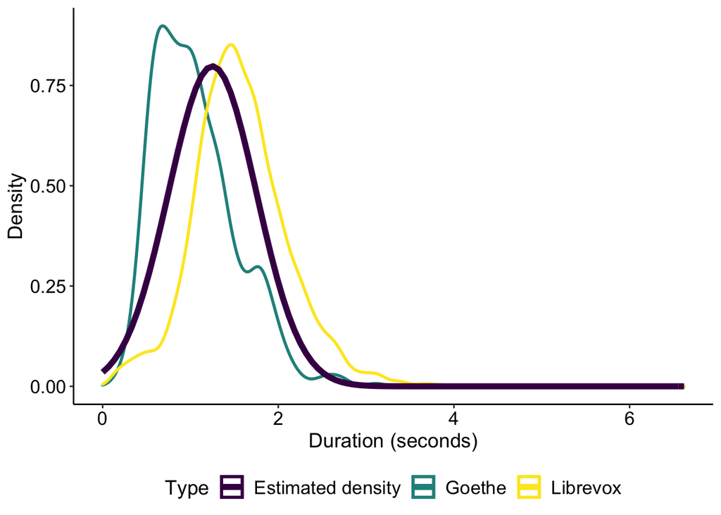

```r
librevox_pauses = read.csv(paste0(LIBREVOX_DATA_DIR, "split_fragments.csv"))
library(viridis)
ggplot() +
  geom_density(data = german_pauses, aes(x = duration, color = "Goethe"), lwd = 1) +
  geom_density(data = librevox_pauses, aes(x = pause_duration, color = "Librevox"), lwd = 1) +
  stat_function(data = data.frame(x = c(0, 6)), aes(x, color = 'Estimated density'), fun = dnorm, n = 101, args = list(mean = 1.25, sd = 0.5), lwd = 2) +
  labs(x = 'Duration (seconds)', y = 'Density', color = 'Type') +
  theme_classic() +
  theme(legend.position = 'bottom', text = element_text(size = 14, color = 'black'), legend.text = element_text(size = 13), axis.text = element_text(size = 13, color = 'black')) +
  scale_colour_viridis_d()
```

```r
#geom_density(data = story_corpus, aes(x = duration, color = "Story corpus"))
ggsave('densities.pdf', device = cairo_pdf)
goethe.fit.norm = fitdist(german_pauses$duration, "norm")
print(goethe.fit.norm)
```

```
## Fitting of the distribution ' norm ' by maximum likelihood
## Parameters:
##       estimate Std. Error
## mean 1.0577381 0.01422560
## sd   0.4690135 0.01005881
```

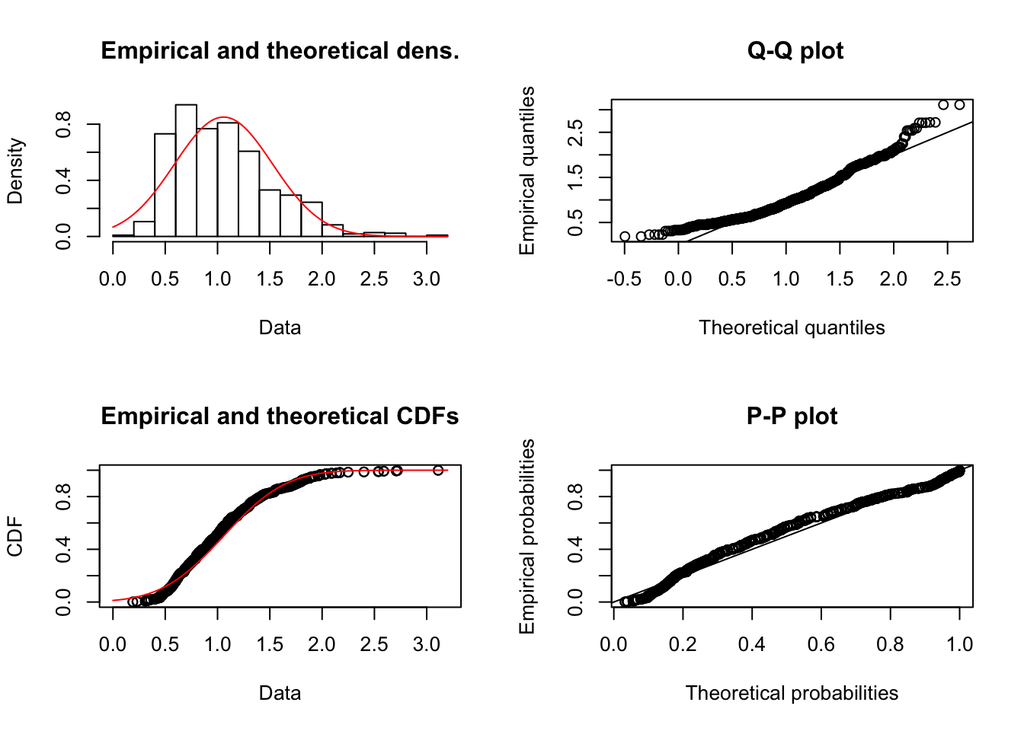

```r
plot(goethe.fit.norm)
```

```r
librevox.fit.norm = fitdist(librevox_pauses$pause_duration, "norm")
print(librevox.fit.norm)
```

```
## Fitting of the distribution ' norm ' by maximum likelihood
## Parameters:
##       estimate  Std. Error
## mean 1.5718311 0.007626213
## sd   0.5464329 0.005392465
```

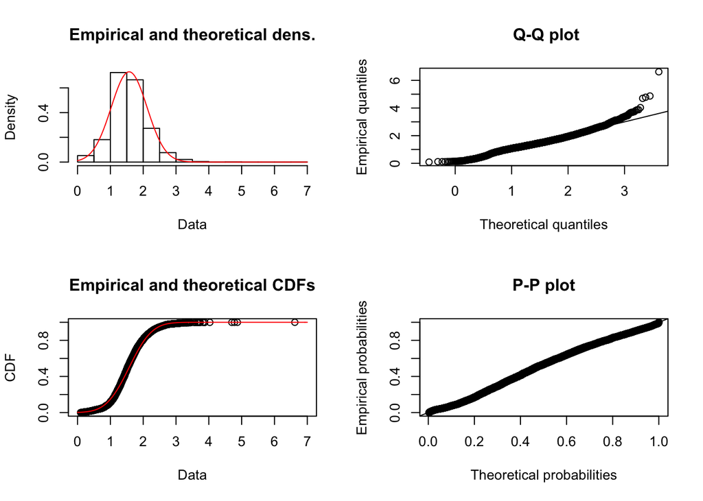

```r
plot(librevox.fit.norm)
```

## Re-synthesize with new distribution

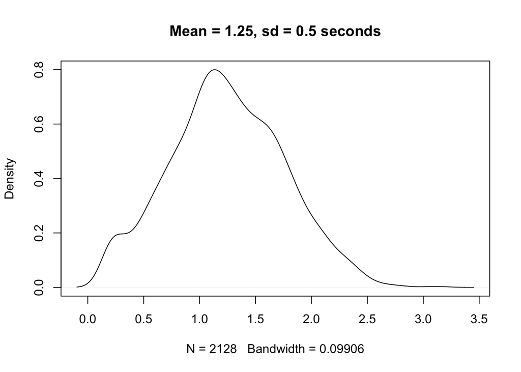

```r
NUM_STORIES = 8
NUM_SPEAKERS = 2
NUM_PAUSES = nrow(story_corpus) +
  (NUM_STORIES * NUM_SPEAKERS) +
  1
set.seed(1)
pauses = rnorm(NUM_PAUSES, 1.25, 0.5)
pauses[pauses < 0.2] = 0.2
plot(density(pauses), main = "Mean = 1.25, sd = 0.5 seconds")
```

```r
SENTENCE_PATH = '../data/stories/sentences/'
NEW_STORY_PATH = '../data/stories/stories_corrected_pauses/'

###########
# Modify word_df
###########
word_df = read.csv(paste0(SENTENCE_PATH, 'relative_word_durations.csv'))
# Female
story_4_F = filter(word_df, story == 4, gender == 'F')
idxs = which(story_4_F$sent_ID == '49a')
story_4_F_before = story_4_F[1:(min(idxs) - 1),]

story_4_F_between = filter(word_df, gender == 'F', story == 1, sent_ID == '55a')
story_4_F_between$sent_ID = '49a'
story_4_F_between$sentence = 102
story_4_F_between$story = 4
between_duration = max(story_4_F_between$t2)

story_4_F_after = story_4_F[(max(idxs) + 1):nrow(story_4_F),]
story_4_F_new = rbind(story_4_F_before, story_4_F_between, story_4_F_after)

# Male
story_4_M = filter(word_df, story == 4, gender == 'M')
idxs = which(story_4_M$sent_ID == '49b')
story_4_M_before = story_4_M[1:(min(idxs) - 1),]

story_4_M_between = filter(word_df, gender == 'M', story == 1, sent_ID == '55a')
story_4_M_between$sent_ID = '49a'
story_4_M_between$sentence = 102
story_4_M_between$story = 4

story_4_M_after = story_4_M[(min(idxs) + 1):nrow(story_4_M),]
story_4_M_after$sentence = story_4_M_after$sentence + 1
story_4_M_new = rbind(story_4_M_before, story_4_M_between, story_4_M_after)

# remove story 4
word_df = word_df[word_df$story != 4,]
word_df = rbind(word_df, story_4_M_new, story_4_F_new)

word_df$gender = factor(word_df$gender, levels = c("M", "F"))
word_df = word_df %>% arrange(gender, story, sentence, t1)

# Modify sentence files
get_filename = function(gender, story, id) {
  return(sprintf('%s%s_%d_%s.wav', SENTENCE_PATH, gender, story, id))
}

file.remove(get_filename('F', 4, '49a'))
```

```
## [1] TRUE
```

```r
file.copy(get_filename('F', 1, '55a'), get_filename('F', 4, '49a'))
```

```
## [1] TRUE
```

```r
file.copy(get_filename('M', 1, '55a'), get_filename('M', 4, '49a'))
```

```
## [1] FALSE
```

```r
# You can see all stories contain 133
word_df %>%
  group_by(gender, story) %>%
  summarise(c = length(unique(sentence)))
```

```
## # A tibble: 16 x 3
## # Groups:   gender [2]
##    gender story     c
##    <fct>  <dbl> <int>
##  1 M          1   133
##  2 M          2   133
##  3 M          3   133
##  4 M          4   133
##  5 M          5   133
##  6 M          6   133
##  7 M          7   133
##  8 M          8   133
##  9 F          1   133
## 10 F          2   133
## 11 F          3   133
## 12 F          4   133
## 13 F          5   133
## 14 F          6   133
## 15 F          7   133
## 16 F          8   133
```

```r
new_word_df = NULL
pause_count = 0
for (g in c('M', 'F')) {
  for (s in 1:8) {
    first_sentence = TRUE
    duration_count = 0
    for (sent in 1:133) {
      id = filter(word_df, gender == g, story == s, sentence == sent)[1, "sent_ID"]

      words_in_sentence = filter(word_df, gender == g, story == s, sent_ID == id)

      sentence_duration_time = max(words_in_sentence$t2)
      words_in_sentence$t1 = words_in_sentence$t1 + duration_count
      words_in_sentence$t2 = words_in_sentence$t2 + duration_count
      new_word_df = rbind(new_word_df, words_in_sentence)

      pause_count = pause_count + 1
      pause = pauses[pause_count]
      # # create silence
      silence_name = 'silence.wav'
      system(sprintf('sox -n -r 11025 -c 1 %s trim 0.0 %f', silence_name, pause))

      filename = get_filename(g, s, id)

      target = sprintf('%s%s_%d.wav', NEW_STORY_PATH, g, s)
      tmp_target = sprintf('%s%s_%d_temp.wav', NEW_STORY_PATH, g, s)

      if (first_sentence) {
        system(sprintf('sox %s %s %s', filename, silence_name, tmp_target))
      } else {
        system(sprintf('sox %s %s %s %s', target, filename, silence_name, tmp_target))
      }
      file.rename(tmp_target, target)
      first_sentence = FALSE

      duration_count = duration_count + pause + sentence_duration_time
    }
  }
}
```

# Annotate

## Syntactic

```r
syntax_new_word_df = read.csv(paste0(NEW_STORY_PATH, 'syntactic_annotation.csv'))
new_word_df = cbind(new_word_df, syntax_new_word_df[c('trace', 'POS_stanf')])
names(new_word_df)[6] = 'sentence_id'
names(new_word_df)[10] = 'stn_pos'
```

## Experimental conditions

```r
story_variables = read_excel('../data/stories/original/Stories_Variables.xlsx', sheet = 3)
column_names = c("condition", "freq_condition", "num_words_sent", "sent_len", "sent_position", "sem_context", "syntactic_precition", "kw_category", "kw_elp_pos", "kw_lfw", "kw_cv", "kw_len", "kw_num_morphs", "kw_num_phons", "kw_primary_syll_stress", "kw_num_sylls", "kw_morph_parse", "kw_sampa", "syn_coca_freq", "synkw_coca_freq")

ids = levels(new_word_df$sentence_id)

fill_roles = function(key, name_role, words, roles) {
  for (subkey in strsplit(key, " |-")[[1]]) {
    idx = which(words == subkey)
    if (length(idx) != 1) {
      print(key)
      print(subkey)
      print(words)
      if (length(idx) == 0) {
        if (key == 'TEAM NAME') {
          next
        } else {
          stop('This may not happen')
        }
      } else {
        warning('Multiple times the same word, taking the last one')
        idx = tail(idx, 1)
      }
    }
    roles[idx] = name_role
  }
  return(roles)
}

for (g in c('M', 'F')) {
  for (s in 1:8) {
    for (sent_ID in ids[grep('b', ids)]) {
      a_sent_ID = stringr::str_replace(sent_ID, 'b', 'a')

      if (s == 4 & a_sent_ID == '49a') {
        s = 1
        a_sent_ID = '55a'
        sent_ID = '55b'
      }

      allowed_IDs = c(a_sent_ID, sent_ID)
      row_idx = new_word_df$sentence_id %in% allowed_IDs &
        new_word_df$gender == g &
        new_word_df$story == s

      meta_row = filter(story_variables, SentID == sent_ID, Story == s)
      if (nrow(meta_row) != 1) {
        stop('This may not happen')
      }

      # a pairs
      words_a = filter(new_word_df, sentence_id == a_sent_ID, gender == g, story == s)$word
      roles_a = rep('', length(words_a))
      semantic_context = stringr::str_replace_all(toupper(meta_row$sem), '<|>', '')
      roles_a = fill_roles(semantic_context, 'prior_context', words_a, roles_a)

      # b pairs
      words_b = filter(new_word_df, sentence_id == sent_ID, gender == g, story == s)$word
      roles_b = rep('', length(words_b))
      keyword = toupper(meta_row$kw)
      roles_b = fill_roles(keyword, 'keyword', words_b, roles_b)

      syntactic_word = stringr::str_replace_all(toupper(meta_row$syn), '\\[|\\]', '')
      roles_b = fill_roles(syntactic_word, 'local_context', words_b, roles_b)

      roles = c(roles_a, roles_b)
      new_word_df[row_idx, "roles"] = roles

      # Global sentence attributes
      for (col in column_names) {
        new_word_df[row_idx, col] = meta_row[[col]]
      }
    }
  }
}
```

```
## [1] "HAD"
## [1] "HAD"
##  [1] HER       EYES      SHIMMERED AS        SHE       BEGAN     TO
##  [8] DESCRIBE  THE       WONDERFUL MORNING   THAT      SHE       HAD
## [15] HAD
## 3748 Levels: A ABACK ABLE ABNORMALLY ABOUT ABOVE ABRUPTLY ... sp
```

```
## [1] "THE PAPER"
## [1] "THE"
##  [1] DEB     TRIED   TO      IGNORE  THE     SAFFRON AS      SHE     SAT
## [10] TO      READ    THE     PAPER
## 3748 Levels: A ABACK ABLE ABNORMALLY ABOUT ABOVE ABRUPTLY ... sp
```

```
## [1] "HAD"
## [1] "HAD"
##  [1] HER       EYES      SHIMMERED AS        SHE       BEGAN     TO
##  [8] DESCRIBE  THE       WONDERFUL MORNING   THAT      SHE       HAD
## [15] HAD
## 3748 Levels: A ABACK ABLE ABNORMALLY ABOUT ABOVE ABRUPTLY ... sp
```

```
## [1] "HER"
## [1] "HER"
##  [1] GRANT   WAS     EXCITED TO      TELL    HER     THAT    HE      KNEW
## [10] JUST    THE     TOPIC   FOR     HER
## 3748 Levels: A ABACK ABLE ABNORMALLY ABOUT ABOVE ABRUPTLY ... sp
```

```
## [1] "SO CALLED"
## [1] "SO"
##  [1] THE       PRANK     STIRRED   UP        A         LOT       OF
##  [8] SO        CALLED    RIVALRY   AND       SO        THE       FOLLOWING
## [15] WEEKS     WERE      CHAOTIC
## 3748 Levels: A ABACK ABLE ABNORMALLY ABOUT ABOVE ABRUPTLY ... sp
```

```
## [1] "TEAM NAME"
## [1] "NAME"
##  [1] HER         PAL         ONCE        TOLD        HER         THAT
##  [7] SHE         WAS         THE         INSPIRATION BEHIND      THEIR
## [13] NEW         TEAM
## 3748 Levels: A ABACK ABLE ABNORMALLY ABOUT ABOVE ABRUPTLY ... sp
## [1] "THE PAPER"
## [1] "THE"
##  [1] DEB     TRIED   TO      IGNORE  THE     SAFFRON AS      SHE     SAT
## [10] TO      READ    THE     PAPER
## 3748 Levels: A ABACK ABLE ABNORMALLY ABOUT ABOVE ABRUPTLY ... sp
```

```
## [1] "HER"
## [1] "HER"
##  [1] GRANT   WAS     EXCITED TO      TELL    HER     THAT    HE      KNEW
## [10] OF      JUST    THE     TOPIC   FOR     HER
## 3748 Levels: A ABACK ABLE ABNORMALLY ABOUT ABOVE ABRUPTLY ... sp
```

```
## [1] "SO CALLED"
## [1] "SO"
##  [1] THE       PRANK     STIRRED   UP        A         LOT       OF
##  [8] SO        CALLED    RIVALRY   AND       SO        THE       FOLLOWING
## [15] WEEKS     WERE      CHAOTIC
## 3748 Levels: A ABACK ABLE ABNORMALLY ABOUT ABOVE ABRUPTLY ... sp
```

```r
# Correct the column names
correct_names = function (df, old_name, new_name){
  if (!old_name %in% names(df)){
    stop('Name not in df')
  }
  idx = which(names(df) == old_name)
  names(df)[idx] = new_name
  return(df)
}

new_word_df = correct_names(new_word_df, 'trace', 'stn_trace')

new_word_df = correct_names(new_word_df, 'freq_condition', 'kw_freq_condition')

new_word_df = correct_names(new_word_df, 'sent_position', 'syntactic_position')
new_word_df = correct_names(new_word_df, 'sem_context', 'local_context')
new_word_df = correct_names(new_word_df, 'syntactic_precition', 'prior_context')

new_word_df = correct_names(new_word_df, 'kw_morph_parse', 'kw_morph')
new_word_df = correct_names(new_word_df, 'kw_sampa', 'kw_phon')

new_word_df = correct_names(new_word_df, 'syn_coca_freq', 'local_coca_freq')
new_word_df = correct_names(new_word_df, 'synkw_coca_freq', 'local_kw_coca_freq')


write.csv(new_word_df, '../public/stories/meta.csv', row.names = F)


delay = word_df %>%
  group_by(gender, story, sent_ID) %>%
  summarise(t1 = t1[1])
sentence_df = new_word_df
for (g in c('M', 'F')) {
  for (s in 1:8) {
    for (id in ids) {
      start_time = filter(delay, gender==g, story==s, sent_ID==id)$t1
      row_idx = sentence_df$gender == g & sentence_df$story == s & sentence_df$sentence_id == id
      minus_time = min(sentence_df[row_idx, "t1"])
      sentence_df[row_idx, "t1"] = sentence_df[row_idx, "t1"] - minus_time + start_time
      sentence_df[row_idx, "t2"] = sentence_df[row_idx, "t2"] - minus_time + start_time

      tg = tg.createNewTextGrid(0, max(sentence_df[row_idx, "t2"]))
      tg = tg.insertNewIntervalTier(tg, 1, "word")
      tg$word$t1 = sentence_df[row_idx, "t1"]
      tg$word$t2 = sentence_df[row_idx, "t2"]
      tg$word$label = sentence_df[row_idx, "word"]
      tg.write(tg, sprintf('../data/stories/sentences/%s_%d_%s.TextGrid', g, s, id))
    }
  }
}

write.csv(sentence_df, '../public/sentences/meta.csv', row.names = F)
```

## Create TextGrids

```r
library(rPraat)
for (s in 1:8) {
  for (g in c("M", "F")) {
    story_df = filter(new_word_df, gender == g, story == s)
    tg = tg.createNewTextGrid(0, max(story_df$t2))
    tg = tg.insertNewIntervalTier(tg, 1, "word")
    tg$word$t1 = story_df$t1
    tg$word$t2 = story_df$t2
    tg$word$label = story_df$word
    tg.write(tg, sprintf('../data/stories/stories_corrected_pauses/%s_%d.TextGrid', g, s))
  }
}
```